# R Bootcamp: Introduction to R Programming

2022-08-17

## Programming in R

While `R` can be used to handle simple arithmetic, `R` is typically used to…

- Manage, organize, and visualize data (Day 1 lecture)
- Perform statistical analyses (using pre-existing packages)
- Develop new statistical techniques
- Evaluate different statistical methods (e.g., simulation studies)

The latter points will require some knowledge of programming in `R`.

## Programming in R

Programming in `R` can help us:

- Generalize our code
- Easily distribute our code to others

> `R` is just a tool. The intelligence of code comes from the *coder*.

## Conditional statements

- We need to “tell” `R` when to do something.
- This can be done by injecting logic into the code (`TRUE/FALSE`)
- Conditional statements are powerful because we can have `R` execute different commands with a simple block of code.

## The `if` statement

The most commonly-used conditional statement is the `if` statement:

```r
if (condition) {
  Execute this code if condition is TRUE
}
```

In English: “If this condition is met, then do this”

```r
if (condition) {
  Execute this code if condition is TRUE
} else {
  Execute this code if condition is FALSE
}
```

## Nesting `if` statements

You can also nest several `if` statements:

```r
if (condition) {
  Execute this code if condition is TRUE
  if (condition2) {
    Execute this code if condition2 is TRUE
  } else {
    Execute this code if condition2 is FALSE
  }
} else {
  Execute this code if condition is FALSE
}
```

How do we tell `R` what the condition we want met is?

## Common Logical Operators

| Operator | What it means? |
| --- | --- |
| `x < y` | `x` is less than `y` |
| `x > y` | `x` is greater than `y` |
| `x == y` | `x` is equal to `y` |
| `x <= y` | `x` is less than (or equal to) `y` |
| `x >= y` | `x` is greater than (or equal to) `y` |
| `x != y` | `x` is not equal to `y` |

Each of these will return either a `TRUE` or `FALSE`.

## Examples

```r
5 == 2
```

```
## [1] FALSE
```

```r
5 >= 2
```

```
## [1] TRUE
```

```r
5 <= 2
```

```
## [1] FALSE
```

## Examples

```r
a = 5; b = 2
a == b
```

```
## [1] FALSE
```

```r
a >= b
```

```
## [1] TRUE
```

```r
a <= b
```

```
## [1] FALSE
```

## Other Logical Operators

| Operator | Returns `TRUE` if… |
| --- | --- |
| `x && y` | `x` and `y` are met |
| `x \|\| y` | `x` and/or `y` are met |

```r
a <- TRUE; b <- FALSE
a && b # Both have to be TRUE
```

```
## [1] FALSE
```

```r
a || b # Only one needs to be TRUE
```

```
## [1] TRUE
```

## A Programmer’s Joke

> A programmer’s partner says: ‘Please go to the store and buy a carton of milk and if they have eggs, get six.’

> The programmer returned with 6 cartons of milk.

> When the partner sees this, and exclaims ‘Why the heck did you buy six cartons of milk?’

> The programmer replied ‘They had eggs’

## Let’s program this

First we have to define a few things:

1. The condition
2. The output

## Let’s program this

First we have to define a few things:

1. The condition (`hasEggs`)
2. The output (`cartonsOfMilk`)

```r
hasEggs <- TRUE
cartonsOfMilk <- NULL
if (hasEggs) {
  cartonsOfMilk <- 6
}
cartonsOfMilk
```

```
## [1] 6
```

## Let’s program this

What happened here?

```r
hasEggs <- FALSE
cartonsOfMilk <- NULL
if (hasEggs) {
  cartonsOfMilk <- 6
}
cartonsOfMilk
```

[output not shown]

## Let’s program this

We need to complete the logical argument (No eggs = 1 carton of milk).

```r
hasEggs <- FALSE
cartonsOfMilk <- NULL
if (hasEggs) {
  cartonsOfMilk <- 6
} else {
  cartonsOfMilk <- 1
}
cartonsOfMilk
```

```
## [1] 1
```

## We can do more complicated loops

```r
a <- -1
b <- 2
if (!is.numeric(a) || !is.numeric(b)) {
  output <- "a is not a number and/or b is not a number"
} else if (a > 0 && b > 0) {
  output <- "Both a and b are positive"
} else if (a < 0 && b < 0) {
  output <- "Both a and b are negative"
} else if (a == 0 || b == 0) {
  output <- "a is 0 and/or b is 0"
} else {
  output <- "a and b have different signs"
}
output
```

```
## [1] "a and b have different signs"
```

## Functions

Recall the previous example:

```r
a <- -1
b <- 2
if (!is.numeric(a) || !is.numeric(b)) {
  output <- "a is not a number and/or b is not a number"
} else if (a > 0 && b > 0) {
  output <- "Both a and b are positive"
} else if (a < 0 && b < 0) {
  output <- "Both a and b are negative"
} else if (a == 0 || b == 0) {
  output <- "a is 0 and/or b is 0"
} else {
  output <- "a and b have different signs"
}
output
```

We have to always define `a` and `b` , execute the conditional statement and call the `output`.

## Functions

We can define a function so that when we call it (with a specific `value`), we will get the `output`.

```r
myFunction <- function(a = 0, b = 0) {
if (!is.numeric(a) || !is.numeric(b)) {
  output <- "a is not a number and/or b is not a number"
} else if (a > 0 && b > 0) {
  output <- "Both a and b are positive"
} else if (a < 0 && b < 0) {
  output <- "Both a and b are negative"
} else if (a == 0 || b == 0) {
  output <- "a is 0 and/or b is 0"
} else {
  output <- "a and b have different signs"
}
return(output)
}
```

## Functions

Now we can just call `myFunction`:

```r
myFunction(a = 0, b = 1)
```

```
## [1] "a is 0 and/or b is 0"
```

```r
myFunction(a = "Hi", b = 10)
```

```
## [1] "a is not a number and/or b is not a number"
```

## Functions

We can also get details of the function:

```r
myFunction
```

```
## function(a = 0, b = 0) {
## if (!is.numeric(a) || !is.numeric(b)) {
##   output <- "a is not a number and/or b is not a number"
## } else if (a > 0 && b > 0) {
##   output <- "Both a and b are positive"
## } else if (a < 0 && b < 0) {
##   output <- "Both a and b are negative"
## } else if (a == 0 || b == 0) {
##   output <- "a is 0 and/or b is 0"
## } else {
##   output <- "a and b have different signs"
## }
## return(output)
## }
## <bytecode: 0x7f94112425e0>
```

## Function

General pseudocode for a function:

`nameOfFunction <- function(argument1, argument2, ...) {expression}`

- Can have multiple inputs (arguments)
- Can have multiple outputs
- Functions need specific/exact instructions to work properly.

## Loops

Loops are great for performing repetitive tasks. Two commonly-used loops are `for` and `while` loops:

- `for`: Execute instructions in the loop for a specified number of times.
- `while`: Execute instructions in the loop until a certain condition is met.

## for loops:

Let’s say we want `R` to print out the numbers 1, 2, and 3.

```r
print(1)
```

```
## [1] 1
```

```r
print(2)
```

```
## [1] 2
```

```r
print(3)
```

```
## [1] 3
```

## for loops:

```r
for (i in 1:3) {
  print(i)
}
```

```
## [1] 1
## [1] 2
## [1] 3
```

## for loops:

What happened here?

```r
j <- 10
for (i in 1:3) {
  print(j)
}
```

```
## [1] 10
## [1] 10
## [1] 10
```

## for loops:

Loops do not have to be sequential

```r
for (i in c(-1, 2, 4, 0, 5, 10)) {
  print(i)
}
```

```
## [1] -1
## [1] 2
## [1] 4
## [1] 0
## [1] 5
## [1] 10
```

## while loops:

Pseudocode:

`while(longical condition is TRUE) { expression }`

What does this do?

```r
i <- 0
while (i <= 4) {
  i <- i + 1
  print(i)
}
```

## while loops:

Pseudocode:

`while(longical condition is TRUE) { expression }`

What does this do?

```r
i <- 0
while (i <= 4) {
  i <- i + 1
  print(i)
}
```

```
## [1] 1
## [1] 2
## [1] 3
## [1] 4
## [1] 5
```

## while loops:

`for` loops can be used to make inefficient `while` loops

```r
for (i in 0:10) {
  if (i <= 4) {
    print(i + 1)
  } else {
    break
  }
}
```

```
## [1] 1
## [1] 2
## [1] 3
## [1] 4
## [1] 5
```

## while loops:

Be careful!

What does this do?

```r
i <- 0
while (i <= 4) {
  print(i)
}
```

## Conclusion:

We learned:

1. How to properly construct conditional statements
2. The basics of developing a function
3. The basics of using a loop for repetitive tasks

## Simulating \(\pi\)

- We will learn how to approximate \(\pi\) using everything we just learned.
- Note: A `pi` function is available in `R`.
- We will estimate \(\pi\) through simulation.

## Throwing darts in a unit square

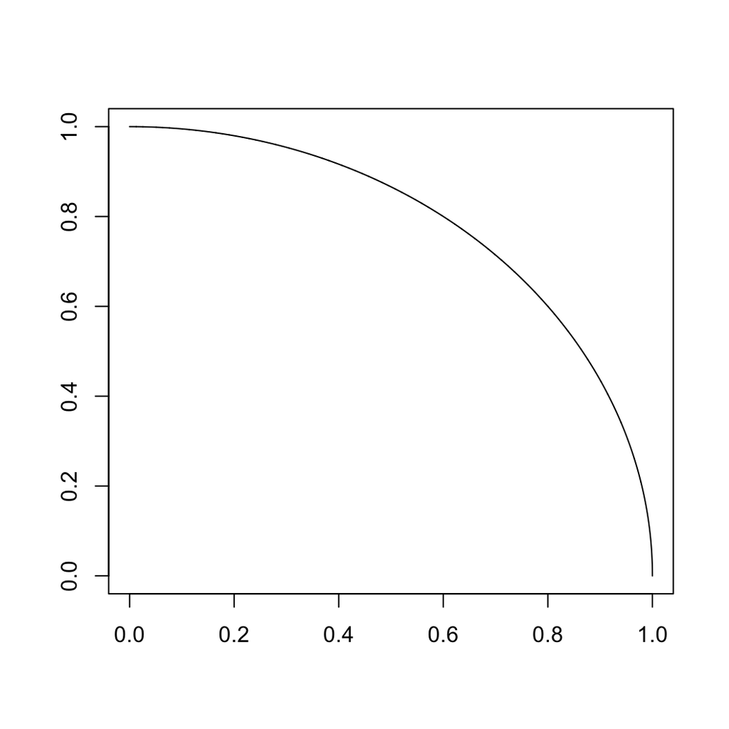

## Throwing darts in a unit square

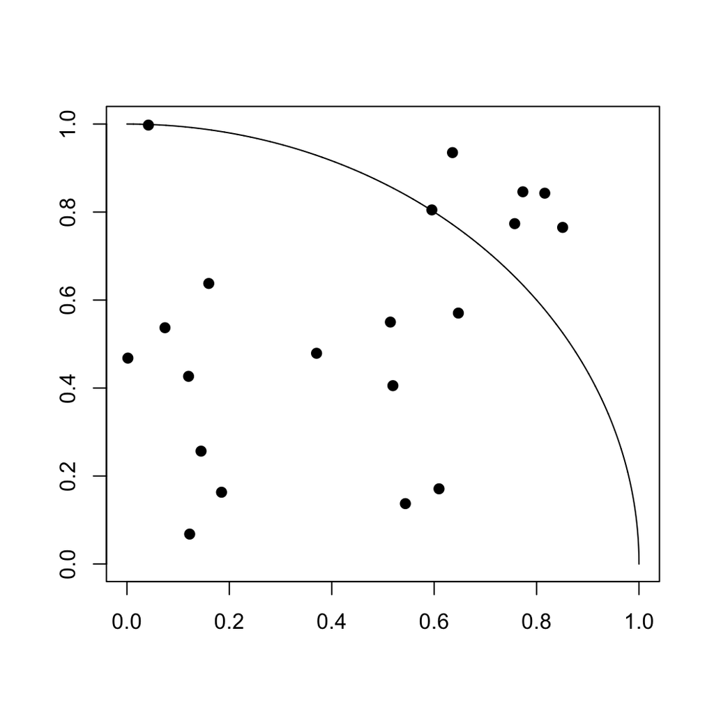

## Throwing darts in a unit square

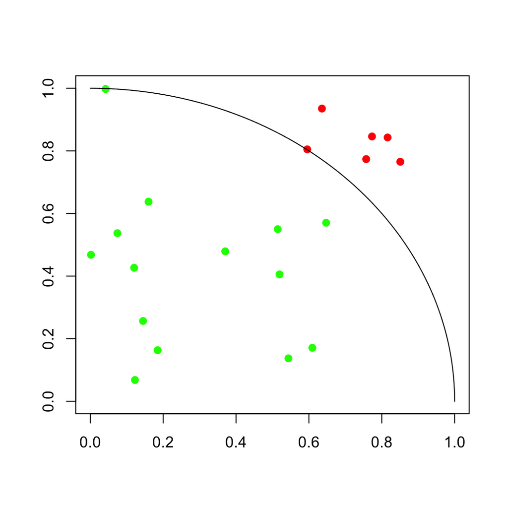

## Throwing darts in a unit square

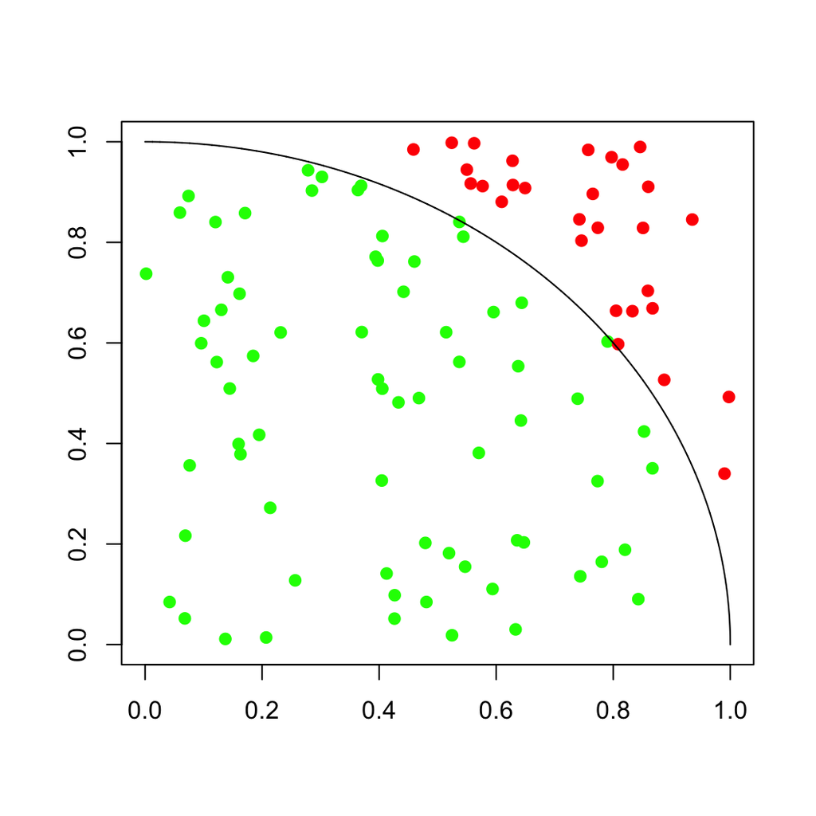

## Throwing darts in a unit square

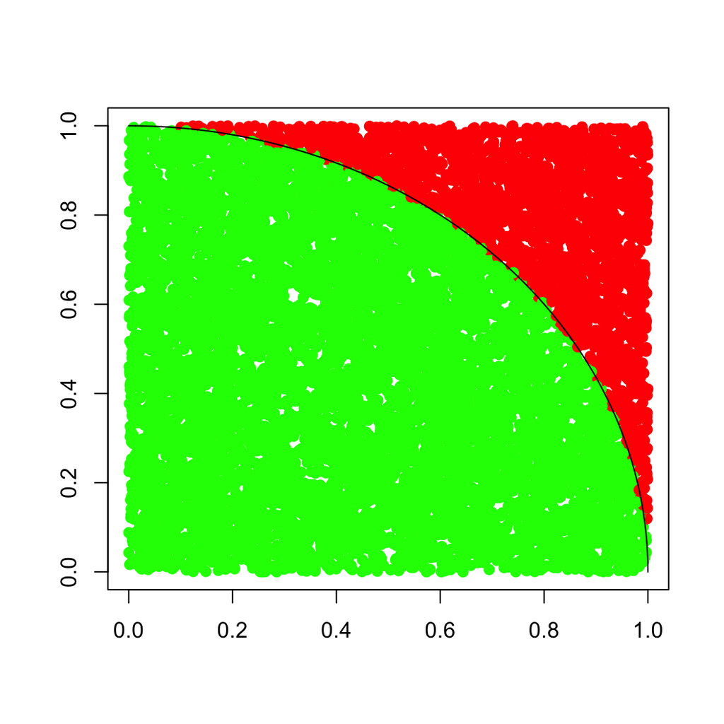

## Simulating \(\pi\)

- We can use a simulation to estimate to area under the curve.
- This is known as a **Monte Carlo** simulation.
  - Algorithms that enable us to calculate probabilities/integrals that may be hard to do analytically.
- Calculating the proportion of “hits” (green dots) will give us an estimate of the area under the quarter arc. \[ p = \frac{\mbox{# of green dots}}{\mbox{Total # of dots}}\]
- A green dot is a coordinate pair \((x, y)\) where \(x^2 + y^2 \leq 1\).
- The area of the quarter arc (of a unit circle) is \(\pi / 4\).
- We can estimate \(\pi\) by \(4 \times p\).

## Exercise:

Your exercise is to develop a function to estimate \(\pi\).

- We want a user-inputted argument for the number of dots (`N`).
- Note: We want `N` to be large so that we have an accurate approximation.

## Exercise:

Hints:

1. To generate `N` dots from a uniform distribution between 0 and 1 we can use the `runif` function:

```r
N <- 100
x <- runif(N, min = 0, max = 1)
y <- runif(N, min = 0, max = 1)
head(x)
```

```
## [1] 0.8645684 0.8519644 0.5925420 0.5187648 0.3018081 0.6112440
```

## Exercise:

1. We want to store the number of `hits` (green dots) that satisfy `x[i]^2 + y[i]^2 <= 1` for `i = 1:N`.

```r
hits <- 0
x[1]^2 + y[1]^2
```

```
## [1] 0.9444421
```

```r
x[1]^2 + y[1]^2 <= 1
```

```
## [1] TRUE
```

If `TRUE` we want to update `hit` (i.e. `hit <- hit + 1`). What happens if it is `FALSE`?

## Exercise:

```r
piSimulator <- function(N = 100) {
  x <- runif(N, min = 0, max = 1)
  y <- runif(N, min = 0, max = 1)
  hit <- 0 # "Hit"-counter
  for(i in ...) {
    # Conditional statement: what needs to be satisfied?
    if (....) {
      hit <- hit + 1
    } else {
      # What happens if condition isn't satisfied?
    }
  }

  p <- # What is p? Hint: sum(hit) =  # of green dots
  # What is the actual value you are trying to calculate?
  result <- # Hint: # of green dots / # of total dots
  return(result)
}
```

## Solution:

```r
piSimulator <- function(N = 100) {
  x <- runif(N, min = 0, max = 1)
  y <- runif(N, min = 0, max = 1)

  hit <- 0
  for(i in 1:N) {
    if (x[i]^2 + y[i]^2 <= 1) {
      hit <- hit + 1
    } else {
      hit
    }
  }
  result <- 4 * sum(hit) / N
  return(result)
}
```

## Solution:

```r
piSimulator(N = 100)
```

```
## [1] 3.12
```

```r
piSimulator(N = 1000)
```

```
## [1] 3.124
```

```r
piSimulator(N = 100000)
```

```
## [1] 3.14064
```

## Solution:

```r
piSimulator2 <- function(N = 100) {
  x <- runif(N, min = 0, max = 1)
  y <- runif(N, min = 0, max = 1)

  return(4 * mean(x^2 + y^2 <= 1))
}
```

## Solution:

```r
piSimulator2(N = 100)
```

```
## [1] 3.56
```

```r
piSimulator2(N = 1000)
```

```
## [1] 3.072
```

```r
piSimulator2(N = 100000)
```

```
## [1] 3.13672
```

## Exercise 2: The Pass Line

- Craps is a dice game in which players bet on the outcomes of a pair of dice.
- Easiest bet is the pass line bet:
  - If the come-out (first) roll is 7 or 11, the bet wins.
  - If the come-out roll is 2, 3 or 12, the bet loses.
  - If the roll is any other value, it establishes a point
    - If, with a point established, that point is rolled again before a 7, the bet wins.
    - If, with a point established, a 7 is rolled before the point is rolled again, the bet loses.
- The probability of winning the pass line is \(\approx 49\%\).
- We can try and program a function to confirm this.

## Exercise 2:

We can simulate dice rolls using the `sample` function:

```r
dice <- sample(1:6, size = 2, replace = TRUE)
dice
```

```
## [1] 3 6
```

```r
sum(dice) # Add the two numbers
```

```
## [1] 9
```

How will we let `R` know what is our come-out roll and what is a roll after the point is established?

## Exercise 2: Skeleton Code

```r
winPassLine <- function(N) {
  win <- 0 # Count the # of times we won
  for(i in 1:N) {
    roll     <- 0 # Count what roll we are on
    decision <- FALSE # TRUE if we win/lose
    while(decision == FALSE) {
      roll <- roll + 1 # Start roll counter
      dice <- sum(sample(1:6, size = 2, replace = TRUE))
      # What happens with first dice roll?
      if (roll == 1 & dice %in% c(7, 11)) {
        win <- win + 1
        decision == TRUE
      } else if (...) {

      } else if (roll == 1 & dice %in% ...) {
          point <- dice
      } else if (...) {

      }
    }
  }
  return(win / N)
}
```